# S02_T05

```python
from IPython.display import Image
%matplotlib inline
import pandas as pd
import datetime as dt
import numpy as np
import matplotlib.pyplot as plt

link1 = r"C:\Users\pacressa\Google Drive\Paul\Formacions\Numbers\CODING\BCN Activa - Data Science (Python)\Sprint 2.2. EEDD i Esctructures de control\S02_T05\DelayedFlights.csv"
link2 = r"C:\Users\pacressa\Google Drive\Paul\Formacions\Numbers\CODING\BCN Activa - Data Science (Python)\Sprint 2.2. EEDD i Esctructures de control\S02_T05\DelayedFlights_short.csv"
link = link1
df = pd.read_csv(link)
```

```python
df[:10]
```

|  | Unnamed: 0 | Year | Month | DayofMonth | DayOfWeek | DepTime | CRSDepTime | ArrTime | CRSArrTime | UniqueCarrier | ... | TaxiIn | TaxiOut | Cancelled | CancellationCode | Diverted | CarrierDelay | WeatherDelay | NASDelay | SecurityDelay | LateAircraftDelay |
| --- | --- | --- | --- | --- | --- | --- | --- | --- | --- | --- | --- | --- | --- | --- | --- | --- | --- | --- | --- | --- | --- |
| 0 | 0 | 2008 | 1 | 3 | 4 | 2003.0 | 1955 | 2211.0 | 2225 | WN | ... | 4.0 | 8.0 | 0 | N | 0 | NaN | NaN | NaN | NaN | NaN |
| 1 | 1 | 2008 | 1 | 3 | 4 | 754.0 | 735 | 1002.0 | 1000 | WN | ... | 5.0 | 10.0 | 0 | N | 0 | NaN | NaN | NaN | NaN | NaN |
| 2 | 2 | 2008 | 1 | 3 | 4 | 628.0 | 620 | 804.0 | 750 | WN | ... | 3.0 | 17.0 | 0 | N | 0 | NaN | NaN | NaN | NaN | NaN |
| 3 | 4 | 2008 | 1 | 3 | 4 | 1829.0 | 1755 | 1959.0 | 1925 | WN | ... | 3.0 | 10.0 | 0 | N | 0 | 2.0 | 0.0 | 0.0 | 0.0 | 32.0 |
| 4 | 5 | 2008 | 1 | 3 | 4 | 1940.0 | 1915 | 2121.0 | 2110 | WN | ... | 4.0 | 10.0 | 0 | N | 0 | NaN | NaN | NaN | NaN | NaN |
| 5 | 6 | 2008 | 1 | 3 | 4 | 1937.0 | 1830 | 2037.0 | 1940 | WN | ... | 3.0 | 7.0 | 0 | N | 0 | 10.0 | 0.0 | 0.0 | 0.0 | 47.0 |
| 6 | 10 | 2008 | 1 | 3 | 4 | 706.0 | 700 | 916.0 | 915 | WN | ... | 5.0 | 19.0 | 0 | N | 0 | NaN | NaN | NaN | NaN | NaN |
| 7 | 11 | 2008 | 1 | 3 | 4 | 1644.0 | 1510 | 1845.0 | 1725 | WN | ... | 6.0 | 8.0 | 0 | N | 0 | 8.0 | 0.0 | 0.0 | 0.0 | 72.0 |
| 8 | 15 | 2008 | 1 | 3 | 4 | 1029.0 | 1020 | 1021.0 | 1010 | WN | ... | 6.0 | 9.0 | 0 | N | 0 | NaN | NaN | NaN | NaN | NaN |
| 9 | 16 | 2008 | 1 | 3 | 4 | 1452.0 | 1425 | 1640.0 | 1625 | WN | ... | 7.0 | 8.0 | 0 | N | 0 | 3.0 | 0.0 | 0.0 | 0.0 | 12.0 |

10 rows × 30 columns

Complete Dataframe:

```python
df[:]
```

|  | Unnamed: 0 | Year | Month | DayofMonth | DayOfWeek | DepTime | CRSDepTime | ArrTime | CRSArrTime | UniqueCarrier | ... | TaxiIn | TaxiOut | Cancelled | CancellationCode | Diverted | CarrierDelay | WeatherDelay | NASDelay | SecurityDelay | LateAircraftDelay |
| --- | --- | --- | --- | --- | --- | --- | --- | --- | --- | --- | --- | --- | --- | --- | --- | --- | --- | --- | --- | --- | --- |
| 0 | 0 | 2008 | 1 | 3 | 4 | 2003.0 | 1955 | 2211.0 | 2225 | WN | ... | 4.0 | 8.0 | 0 | N | 0 | NaN | NaN | NaN | NaN | NaN |
| 1 | 1 | 2008 | 1 | 3 | 4 | 754.0 | 735 | 1002.0 | 1000 | WN | ... | 5.0 | 10.0 | 0 | N | 0 | NaN | NaN | NaN | NaN | NaN |
| 2 | 2 | 2008 | 1 | 3 | 4 | 628.0 | 620 | 804.0 | 750 | WN | ... | 3.0 | 17.0 | 0 | N | 0 | NaN | NaN | NaN | NaN | NaN |
| 3 | 4 | 2008 | 1 | 3 | 4 | 1829.0 | 1755 | 1959.0 | 1925 | WN | ... | 3.0 | 10.0 | 0 | N | 0 | 2.0 | 0.0 | 0.0 | 0.0 | 32.0 |
| 4 | 5 | 2008 | 1 | 3 | 4 | 1940.0 | 1915 | 2121.0 | 2110 | WN | ... | 4.0 | 10.0 | 0 | N | 0 | NaN | NaN | NaN | NaN | NaN |
| ... | ... | ... | ... | ... | ... | ... | ... | ... | ... | ... | ... | ... | ... | ... | ... | ... | ... | ... | ... | ... | ... |
| 1936753 | 7009710 | 2008 | 12 | 13 | 6 | 1250.0 | 1220 | 1617.0 | 1552 | DL | ... | 9.0 | 18.0 | 0 | N | 0 | 3.0 | 0.0 | 0.0 | 0.0 | 22.0 |
| 1936754 | 7009717 | 2008 | 12 | 13 | 6 | 657.0 | 600 | 904.0 | 749 | DL | ... | 15.0 | 34.0 | 0 | N | 0 | 0.0 | 57.0 | 18.0 | 0.0 | 0.0 |
| 1936755 | 7009718 | 2008 | 12 | 13 | 6 | 1007.0 | 847 | 1149.0 | 1010 | DL | ... | 8.0 | 32.0 | 0 | N | 0 | 1.0 | 0.0 | 19.0 | 0.0 | 79.0 |
| 1936756 | 7009726 | 2008 | 12 | 13 | 6 | 1251.0 | 1240 | 1446.0 | 1437 | DL | ... | 13.0 | 13.0 | 0 | N | 0 | NaN | NaN | NaN | NaN | NaN |
| 1936757 | 7009727 | 2008 | 12 | 13 | 6 | 1110.0 | 1103 | 1413.0 | 1418 | DL | ... | 8.0 | 11.0 | 0 | N | 0 | NaN | NaN | NaN | NaN | NaN |

1936758 rows × 30 columns

Merging Year/Month/Day into one single column 'Date':

```python
df['Date'] = df['Year'].astype(str) + "-" + df['Month'].astype(str) + "-" + df['DayofMonth'].astype(str)
rankings_df = df.copy()   #we make a copy to use it for the final exercices
df[:10]
```

|  | Unnamed: 0 | Year | Month | DayofMonth | DayOfWeek | DepTime | CRSDepTime | ArrTime | CRSArrTime | UniqueCarrier | ... | TaxiOut | Cancelled | CancellationCode | Diverted | CarrierDelay | WeatherDelay | NASDelay | SecurityDelay | LateAircraftDelay | Date |
| --- | --- | --- | --- | --- | --- | --- | --- | --- | --- | --- | --- | --- | --- | --- | --- | --- | --- | --- | --- | --- | --- |
| 0 | 0 | 2008 | 1 | 3 | 4 | 2003.0 | 1955 | 2211.0 | 2225 | WN | ... | 8.0 | 0 | N | 0 | NaN | NaN | NaN | NaN | NaN | 2008-1-3 |
| 1 | 1 | 2008 | 1 | 3 | 4 | 754.0 | 735 | 1002.0 | 1000 | WN | ... | 10.0 | 0 | N | 0 | NaN | NaN | NaN | NaN | NaN | 2008-1-3 |
| 2 | 2 | 2008 | 1 | 3 | 4 | 628.0 | 620 | 804.0 | 750 | WN | ... | 17.0 | 0 | N | 0 | NaN | NaN | NaN | NaN | NaN | 2008-1-3 |
| 3 | 4 | 2008 | 1 | 3 | 4 | 1829.0 | 1755 | 1959.0 | 1925 | WN | ... | 10.0 | 0 | N | 0 | 2.0 | 0.0 | 0.0 | 0.0 | 32.0 | 2008-1-3 |
| 4 | 5 | 2008 | 1 | 3 | 4 | 1940.0 | 1915 | 2121.0 | 2110 | WN | ... | 10.0 | 0 | N | 0 | NaN | NaN | NaN | NaN | NaN | 2008-1-3 |
| 5 | 6 | 2008 | 1 | 3 | 4 | 1937.0 | 1830 | 2037.0 | 1940 | WN | ... | 7.0 | 0 | N | 0 | 10.0 | 0.0 | 0.0 | 0.0 | 47.0 | 2008-1-3 |
| 6 | 10 | 2008 | 1 | 3 | 4 | 706.0 | 700 | 916.0 | 915 | WN | ... | 19.0 | 0 | N | 0 | NaN | NaN | NaN | NaN | NaN | 2008-1-3 |
| 7 | 11 | 2008 | 1 | 3 | 4 | 1644.0 | 1510 | 1845.0 | 1725 | WN | ... | 8.0 | 0 | N | 0 | 8.0 | 0.0 | 0.0 | 0.0 | 72.0 | 2008-1-3 |
| 8 | 15 | 2008 | 1 | 3 | 4 | 1029.0 | 1020 | 1021.0 | 1010 | WN | ... | 9.0 | 0 | N | 0 | NaN | NaN | NaN | NaN | NaN | 2008-1-3 |
| 9 | 16 | 2008 | 1 | 3 | 4 | 1452.0 | 1425 | 1640.0 | 1625 | WN | ... | 8.0 | 0 | N | 0 | 3.0 | 0.0 | 0.0 | 0.0 | 12.0 | 2008-1-3 |

10 rows × 31 columns

Setting 'Date' as the index and deleting the columns 'Year','Month','Unnamed','DayofMonth'

```python
df = df.set_index('Date')
df = df.drop(columns=['Year','Month','DayofMonth','Unnamed: 0', "Cancelled", "Diverted"])
df[:10]
```

| Date | DayOfWeek | DepTime | CRSDepTime | ArrTime | CRSArrTime | UniqueCarrier | FlightNum | TailNum | ActualElapsedTime | CRSElapsedTime | ... | Dest | Distance | TaxiIn | TaxiOut | CancellationCode | CarrierDelay | WeatherDelay | NASDelay | SecurityDelay | LateAircraftDelay |
| --- | --- | --- | --- | --- | --- | --- | --- | --- | --- | --- | --- | --- | --- | --- | --- | --- | --- | --- | --- | --- | --- |
| 2008-1-3 | 4 | 2003.0 | 1955 | 2211.0 | 2225 | WN | 335 | N712SW | 128.0 | 150.0 | ... | TPA | 810 | 4.0 | 8.0 | N | NaN | NaN | NaN | NaN | NaN |
| 2008-1-3 | 4 | 754.0 | 735 | 1002.0 | 1000 | WN | 3231 | N772SW | 128.0 | 145.0 | ... | TPA | 810 | 5.0 | 10.0 | N | NaN | NaN | NaN | NaN | NaN |
| 2008-1-3 | 4 | 628.0 | 620 | 804.0 | 750 | WN | 448 | N428WN | 96.0 | 90.0 | ... | BWI | 515 | 3.0 | 17.0 | N | NaN | NaN | NaN | NaN | NaN |
| 2008-1-3 | 4 | 1829.0 | 1755 | 1959.0 | 1925 | WN | 3920 | N464WN | 90.0 | 90.0 | ... | BWI | 515 | 3.0 | 10.0 | N | 2.0 | 0.0 | 0.0 | 0.0 | 32.0 |
| 2008-1-3 | 4 | 1940.0 | 1915 | 2121.0 | 2110 | WN | 378 | N726SW | 101.0 | 115.0 | ... | JAX | 688 | 4.0 | 10.0 | N | NaN | NaN | NaN | NaN | NaN |
| 2008-1-3 | 4 | 1937.0 | 1830 | 2037.0 | 1940 | WN | 509 | N763SW | 240.0 | 250.0 | ... | LAS | 1591 | 3.0 | 7.0 | N | 10.0 | 0.0 | 0.0 | 0.0 | 47.0 |
| 2008-1-3 | 4 | 706.0 | 700 | 916.0 | 915 | WN | 100 | N690SW | 130.0 | 135.0 | ... | MCO | 828 | 5.0 | 19.0 | N | NaN | NaN | NaN | NaN | NaN |
| 2008-1-3 | 4 | 1644.0 | 1510 | 1845.0 | 1725 | WN | 1333 | N334SW | 121.0 | 135.0 | ... | MCO | 828 | 6.0 | 8.0 | N | 8.0 | 0.0 | 0.0 | 0.0 | 72.0 |
| 2008-1-3 | 4 | 1029.0 | 1020 | 1021.0 | 1010 | WN | 2272 | N263WN | 52.0 | 50.0 | ... | MDW | 162 | 6.0 | 9.0 | N | NaN | NaN | NaN | NaN | NaN |
| 2008-1-3 | 4 | 1452.0 | 1425 | 1640.0 | 1625 | WN | 675 | N286WN | 228.0 | 240.0 | ... | PHX | 1489 | 7.0 | 8.0 | N | 3.0 | 0.0 | 0.0 | 0.0 | 12.0 |

10 rows × 24 columns

Swap number day of the week by its worded version (e.g. 1 = Monday)

```python
weekday={0:'Sunday', 1:'Monday', 2:'Tuesday', 3:'Wednesday', 4:'Thursday', 5:'Friday', 6:'Saturday'}

df["DayOfWeek"] = df["DayOfWeek"].replace(weekday)
df[:10]
```

| Date | DayOfWeek | DepTime | CRSDepTime | ArrTime | CRSArrTime | UniqueCarrier | FlightNum | TailNum | ActualElapsedTime | CRSElapsedTime | ... | Dest | Distance | TaxiIn | TaxiOut | CancellationCode | CarrierDelay | WeatherDelay | NASDelay | SecurityDelay | LateAircraftDelay |
| --- | --- | --- | --- | --- | --- | --- | --- | --- | --- | --- | --- | --- | --- | --- | --- | --- | --- | --- | --- | --- | --- |
| 2008-1-3 | Thursday | 2003.0 | 1955 | 2211.0 | 2225 | WN | 335 | N712SW | 128.0 | 150.0 | ... | TPA | 810 | 4.0 | 8.0 | N | NaN | NaN | NaN | NaN | NaN |
| 2008-1-3 | Thursday | 754.0 | 735 | 1002.0 | 1000 | WN | 3231 | N772SW | 128.0 | 145.0 | ... | TPA | 810 | 5.0 | 10.0 | N | NaN | NaN | NaN | NaN | NaN |
| 2008-1-3 | Thursday | 628.0 | 620 | 804.0 | 750 | WN | 448 | N428WN | 96.0 | 90.0 | ... | BWI | 515 | 3.0 | 17.0 | N | NaN | NaN | NaN | NaN | NaN |
| 2008-1-3 | Thursday | 1829.0 | 1755 | 1959.0 | 1925 | WN | 3920 | N464WN | 90.0 | 90.0 | ... | BWI | 515 | 3.0 | 10.0 | N | 2.0 | 0.0 | 0.0 | 0.0 | 32.0 |
| 2008-1-3 | Thursday | 1940.0 | 1915 | 2121.0 | 2110 | WN | 378 | N726SW | 101.0 | 115.0 | ... | JAX | 688 | 4.0 | 10.0 | N | NaN | NaN | NaN | NaN | NaN |
| 2008-1-3 | Thursday | 1937.0 | 1830 | 2037.0 | 1940 | WN | 509 | N763SW | 240.0 | 250.0 | ... | LAS | 1591 | 3.0 | 7.0 | N | 10.0 | 0.0 | 0.0 | 0.0 | 47.0 |
| 2008-1-3 | Thursday | 706.0 | 700 | 916.0 | 915 | WN | 100 | N690SW | 130.0 | 135.0 | ... | MCO | 828 | 5.0 | 19.0 | N | NaN | NaN | NaN | NaN | NaN |
| 2008-1-3 | Thursday | 1644.0 | 1510 | 1845.0 | 1725 | WN | 1333 | N334SW | 121.0 | 135.0 | ... | MCO | 828 | 6.0 | 8.0 | N | 8.0 | 0.0 | 0.0 | 0.0 | 72.0 |
| 2008-1-3 | Thursday | 1029.0 | 1020 | 1021.0 | 1010 | WN | 2272 | N263WN | 52.0 | 50.0 | ... | MDW | 162 | 6.0 | 9.0 | N | NaN | NaN | NaN | NaN | NaN |
| 2008-1-3 | Thursday | 1452.0 | 1425 | 1640.0 | 1625 | WN | 675 | N286WN | 228.0 | 240.0 | ... | PHX | 1489 | 7.0 | 8.0 | N | 3.0 | 0.0 | 0.0 | 0.0 | 12.0 |

10 rows × 24 columns

## - Exercici 2

Fes un informe complet del data set:.

### - Troba quantes dades faltants hi ha per columna

```python
x = df.isnull().sum()    #count the number of NaNs on each column

df_NaNs = df.copy()    #make a copy of the original DF
df_NaNs.reset_index(inplace=True)    #from the copy, eliminate the 'Date' index...
df_NaNs.drop("Date",axis=1,inplace=True)
df_NaNs.drop(df_NaNs.index[:],0,inplace=True)  #... and all the existing rows
df_empty = df_NaNs.copy()
df_NaNs.loc['NaNs'] = x   #add one last row with the count of NaNs...
o = df_NaNs != 0    #... that will hide those with no value
df_NaNs = df_NaNs[o].dropna(how='any', axis=1)
df_NaNs
```

|  | ArrTime | TailNum | ActualElapsedTime | CRSElapsedTime | AirTime | ArrDelay | TaxiIn | TaxiOut | CarrierDelay | WeatherDelay | NASDelay | SecurityDelay | LateAircraftDelay |
| --- | --- | --- | --- | --- | --- | --- | --- | --- | --- | --- | --- | --- | --- |
| NaNs | 7110.0 | 5 | 8387.0 | 198.0 | 8387.0 | 8387.0 | 7110.0 | 455.0 | 689270.0 | 689270.0 | 689270.0 | 689270.0 | 689270.0 |

Cleaning the table one last time, leaving only relevant columns:

```python
df = df.dropna(how='any', axis=0)         #deleting all the NaN values
df["DepTime"] = df["DepTime"].astype(int)
df["ArrTime"] = df["ArrTime"].astype(int)
df = df.drop(columns=["TailNum","CancellationCode", "TaxiIn", "TaxiOut", "CRSDepTime", "CRSArrTime", "ActualElapsedTime", "CRSElapsedTime"])
df["DepTime"] = df["DepTime"].astype(int)
df["ArrTime"] = df["ArrTime"].astype(int)
pd.set_option("max_columns", None)
df[:]
df.loc["2008-9-9"]
```

| Date | DayOfWeek | DepTime | ArrTime | UniqueCarrier | FlightNum | AirTime | ArrDelay | DepDelay | Origin | Dest | Distance | CarrierDelay | WeatherDelay | NASDelay | SecurityDelay | LateAircraftDelay |
| --- | --- | --- | --- | --- | --- | --- | --- | --- | --- | --- | --- | --- | --- | --- | --- | --- |
| 2008-9-9 | Tuesday | 843 | 959 | WN | 368 | 122.0 | 64.0 | 78.0 | ABQ | OAK | 889 | 64.0 | 0.0 | 0.0 | 0.0 | 0.0 |
| 2008-9-9 | Tuesday | 1825 | 1827 | WN | 1397 | 54.0 | 27.0 | 30.0 | ABQ | TUS | 321 | 0.0 | 0.0 | 0.0 | 0.0 | 27.0 |
| 2008-9-9 | Tuesday | 906 | 1031 | WN | 35 | 72.0 | 41.0 | 26.0 | ALB | BWI | 288 | 0.0 | 26.0 | 15.0 | 0.0 | 0.0 |
| 2008-9-9 | Tuesday | 1352 | 1459 | WN | 302 | 56.0 | 34.0 | 37.0 | ALB | BWI | 288 | 0.0 | 0.0 | 0.0 | 0.0 | 34.0 |
| 2008-9-9 | Tuesday | 1122 | 1226 | WN | 21 | 53.0 | 111.0 | 112.0 | AMA | DAL | 324 | 0.0 | 0.0 | 0.0 | 0.0 | 111.0 |
| ... | ... | ... | ... | ... | ... | ... | ... | ... | ... | ... | ... | ... | ... | ... | ... | ... |
| 2008-9-9 | Tuesday | 1224 | 1439 | DL | 1917 | 45.0 | 116.0 | 54.0 | BOS | LGA | 185 | 0.0 | 0.0 | 116.0 | 0.0 | 0.0 |
| 2008-9-9 | Tuesday | 1344 | 1503 | DL | 1921 | 46.0 | 22.0 | 14.0 | BOS | LGA | 185 | 0.0 | 0.0 | 22.0 | 0.0 | 0.0 |
| 2008-9-9 | Tuesday | 1517 | 1620 | DL | 1924 | 44.0 | 36.0 | 47.0 | LGA | BOS | 185 | 2.0 | 4.0 | 0.0 | 0.0 | 30.0 |
| 2008-9-9 | Tuesday | 1647 | 1757 | DL | 1927 | 45.0 | 19.0 | 17.0 | BOS | LGA | 185 | 0.0 | 0.0 | 2.0 | 0.0 | 17.0 |
| 2008-9-9 | Tuesday | 800 | 912 | DL | 1942 | 46.0 | 25.0 | 30.0 | DCA | LGA | 214 | 0.0 | 0.0 | 25.0 | 0.0 | 0.0 |

2880 rows × 16 columns

### - Resumeix estadísticament les columnes d’interès

```python
df_stats = df_empty.copy()
x = ["AirTime", "ArrDelay", "DepDelay","Distance", "CarrierDelay", "WeatherDelay", "NASDelay", "LateAircraftDelay"]
df_stats = df_stats.filter(x)

avg = np.around(np.average(df[x], axis=0),2)
median = np.median(df[x], axis=0)
mode = df[x].mode(axis=0, numeric_only=False, dropna=True)  #make list of each column's top mode values
mode = np.array(mode.loc[0]).astype(int)                      #take only the first of the top mode values
rang = np.max(df[x], axis=0) - np.min(df[x], axis=0)
std = np.around(np.std(df[x]),0)

df_stats.loc['Average'] = avg
df_stats.loc['Median'] = median
df_stats.loc['Mode'] = mode
df_stats.loc['Range'] = rang
df_stats.loc['Standard deviation'] = std

cols = list(df_stats.columns)
a, b = cols.index('ArrDelay'), cols.index('Distance')  # reorder the columns to make it prettier
cols[b], cols[a] = cols[a], cols[b]
df_stats = df_stats[cols].astype(int)
df_stats
```

|  | AirTime | Distance | DepDelay | ArrDelay | CarrierDelay | WeatherDelay | NASDelay | LateAircraftDelay |
| --- | --- | --- | --- | --- | --- | --- | --- | --- |
| Average | 107 | 741 | 59 | 63 | 19 | 3 | 15 | 25 |
| Median | 90 | 595 | 41 | 43 | 2 | 0 | 2 | 8 |
| Mode | 45 | 337 | 25 | 15 | 0 | 0 | 0 | 0 |
| Range | 1091 | 4951 | 2461 | 2446 | 2436 | 1352 | 1357 | 1316 |
| Standard deviation | 68 | 559 | 60 | 61 | 44 | 21 | 34 | 42 |

... or what would've saved me a lot of time if I knew before :') :

```python
df[x].describe().astype(int)       #function to make an statistic brief, integrated in pandas
```

|  | AirTime | ArrDelay | DepDelay | Distance | CarrierDelay | WeatherDelay | NASDelay | LateAircraftDelay |
| --- | --- | --- | --- | --- | --- | --- | --- | --- |
| count | 1247486 | 1247486 | 1247486 | 1247486 | 1247486 | 1247486 | 1247486 | 1247486 |
| mean | 107 | 63 | 59 | 741 | 19 | 3 | 15 | 25 |
| std | 68 | 60 | 59 | 559 | 43 | 21 | 33 | 42 |
| min | 0 | 15 | 6 | 11 | 0 | 0 | 0 | 0 |
| 25% | 58 | 26 | 24 | 334 | 0 | 0 | 0 | 0 |
| 50% | 90 | 43 | 41 | 595 | 2 | 0 | 2 | 8 |
| 75% | 136 | 79 | 75 | 972 | 21 | 0 | 15 | 33 |
| max | 1091 | 2461 | 2467 | 4962 | 2436 | 1352 | 1357 | 1316 |

### - Crea columnes noves (velocitat mitjana del vol, si ha arribat tard o no...)

```python
df_filt = df[x].copy()
df_filt["AverageVelocity"] = df_filt["AirTime"] + df_filt["Distance"]  #create avg vel column
delay_list = df_filt.columns.str.contains("Delay")                  #list all the columns with "delay" included

df_delays = df_filt.loc[:,delay_list].copy()                    #dataframe with all columns with "not true" on the list
df_not_delays = df_filt.loc[:,~delay_list]

any_delay = (df_delays != 0)                                    #check if there's been any delay in the dataframe (row by row)
df_not_delays["AnyDelay?"] = (any_delay == False).any(axis=1)
df_not_delays[:10]
```

| Date | AirTime | Distance | AverageVelocity | AnyDelay? |
| --- | --- | --- | --- | --- |
| 2008-1-3 | 77.0 | 515 | 592.0 | True |
| 2008-1-3 | 230.0 | 1591 | 1821.0 | True |
| 2008-1-3 | 107.0 | 828 | 935.0 | True |
| 2008-1-3 | 213.0 | 1489 | 1702.0 | True |
| 2008-1-3 | 110.0 | 838 | 948.0 | True |
| 2008-1-3 | 49.0 | 220 | 269.0 | True |
| 2008-1-3 | 47.0 | 220 | 267.0 | True |
| 2008-1-3 | 143.0 | 1093 | 1236.0 | True |
| 2008-1-3 | 134.0 | 972 | 1106.0 | True |
| 2008-1-3 | 118.0 | 765 | 883.0 | True |

```python
#we will create a new dataframe to use it as a base for the next exercices
y = ["Date", "Year", "Month", "DayofMonth", "DayOfWeek","AirTime", "Distance", "UniqueCarrier", "FlightNum", "Origin", "Dest"] + list(df_delays)
rankings_df = rankings_df[y]
rankings_df[:]
```

|  | Date | Year | Month | DayofMonth | DayOfWeek | AirTime | Distance | UniqueCarrier | FlightNum | Origin | Dest | ArrDelay | DepDelay | CarrierDelay | WeatherDelay | NASDelay | LateAircraftDelay |
| --- | --- | --- | --- | --- | --- | --- | --- | --- | --- | --- | --- | --- | --- | --- | --- | --- | --- |
| 0 | 2008-1-3 | 2008 | 1 | 3 | 4 | 116.0 | 810 | WN | 335 | IAD | TPA | -14.0 | 8.0 | NaN | NaN | NaN | NaN |
| 1 | 2008-1-3 | 2008 | 1 | 3 | 4 | 113.0 | 810 | WN | 3231 | IAD | TPA | 2.0 | 19.0 | NaN | NaN | NaN | NaN |
| 2 | 2008-1-3 | 2008 | 1 | 3 | 4 | 76.0 | 515 | WN | 448 | IND | BWI | 14.0 | 8.0 | NaN | NaN | NaN | NaN |
| 3 | 2008-1-3 | 2008 | 1 | 3 | 4 | 77.0 | 515 | WN | 3920 | IND | BWI | 34.0 | 34.0 | 2.0 | 0.0 | 0.0 | 32.0 |
| 4 | 2008-1-3 | 2008 | 1 | 3 | 4 | 87.0 | 688 | WN | 378 | IND | JAX | 11.0 | 25.0 | NaN | NaN | NaN | NaN |
| ... | ... | ... | ... | ... | ... | ... | ... | ... | ... | ... | ... | ... | ... | ... | ... | ... | ... |
| 1936753 | 2008-12-13 | 2008 | 12 | 13 | 6 | 120.0 | 906 | DL | 1621 | MSP | ATL | 25.0 | 30.0 | 3.0 | 0.0 | 0.0 | 22.0 |
| 1936754 | 2008-12-13 | 2008 | 12 | 13 | 6 | 78.0 | 481 | DL | 1631 | RIC | ATL | 75.0 | 57.0 | 0.0 | 57.0 | 18.0 | 0.0 |
| 1936755 | 2008-12-13 | 2008 | 12 | 13 | 6 | 122.0 | 689 | DL | 1631 | ATL | IAH | 99.0 | 80.0 | 1.0 | 0.0 | 19.0 | 79.0 |
| 1936756 | 2008-12-13 | 2008 | 12 | 13 | 6 | 89.0 | 533 | DL | 1639 | IAD | ATL | 9.0 | 11.0 | NaN | NaN | NaN | NaN |
| 1936757 | 2008-12-13 | 2008 | 12 | 13 | 6 | 104.0 | 874 | DL | 1641 | SAT | ATL | -5.0 | 7.0 | NaN | NaN | NaN | NaN |

1936758 rows × 17 columns

### Quins són els vols més llargs? I els més endarrerits? (+ plot x2) [vols]

```python
rankings_df["Date/Flight"] = rankings_df["Date"] + " (" + rankings_df["UniqueCarrier"] + rankings_df["FlightNum"].astype(str) + ")"
rankings_df = rankings_df.set_index("Date/Flight")

most_df = rankings_df.copy()
most_df["TotalDelay"] = most_df["ArrDelay"] + most_df["DepDelay"]

print("TOP5 LONGER FLIGHTS (time):\n\n",
      most_df[["AirTime", "Origin", "Dest"]].sort_values(by="AirTime", ascending=False)[:5], "\n")

print("TOP5 LONGER FLIGHTS (distance):\n\n",
      most_df[["Distance", "Origin", "Dest"]].sort_values(by="Distance", ascending=False)[:5], "\n")
print("TOP5 DELAYED FLIGHTS (minutes):\n\n",
      most_df[["TotalDelay", "Origin", "Dest"]].sort_values(by="TotalDelay", ascending=False)[:5])
```

```
TOP5 LONGER FLIGHTS (time):

                   AirTime Origin Dest
Date/Flight
2008-9-9 (HA21)    1091.0    SEA  HNL
2008-8-19 (HA28)    733.0    HNL  SEA
2008-2-21 (CO15)    664.0    EWR  HNL
2008-3-21 (CO15)    655.0    EWR  HNL
2008-3-27 (CO15)    654.0    EWR  HNL

TOP5 LONGER FLIGHTS (distance):

                    Distance Origin Dest
Date/Flight
2008-7-18 (CO14)       4962    HNL  EWR
2008-12-20 (CO14)      4962    HNL  EWR
2008-4-25 (CO15)       4962    EWR  HNL
2008-12-16 (CO14)      4962    HNL  EWR
2008-1-13 (CO15)       4962    EWR  HNL

TOP5 DELAYED FLIGHTS (minutes):

                     TotalDelay Origin Dest
Date/Flight
2008-4-10 (NW1699)      4920.0    CLT  MSP
2008-2-3 (NW808)        4918.0    HNL  MSP
2008-5-6 (NW1107)       3903.0    RSW  DTW
2008-6-20 (MQ3538)      3417.0    LIT  DFW
2008-12-19 (NW357)      3252.0    BOS  MSP
```

### Average values per month (4 subplots):

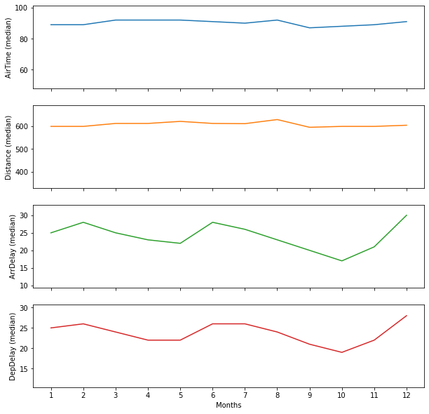

```python
months_df = rankings_df.copy()
x = ["AirTime", "Distance", "ArrDelay", "DepDelay", "Month"]
months_df = months_df[x].groupby("Month").aggregate(np.median)  #grouping the Y axis by "Year" calculating the sum on each column

axes = months_df.plot(figsize=(10, 10), subplots=True, sharex=True, legend=False)     #set up of the subplots
for i in range(4):                                                                    #loop that will design subplots 4 times
    axes[i].set(ylabel = (x[i] + " (median)"), ylim = [(months_df[x[i]].min()*0.55),(months_df[x[i]].max()*1.1)], xlabel= "Months")

plt.xticks([1,2,3,4,5,6,7,8,9,10,11,12])
plt.show()
```

### Average per weekday (4 plots):

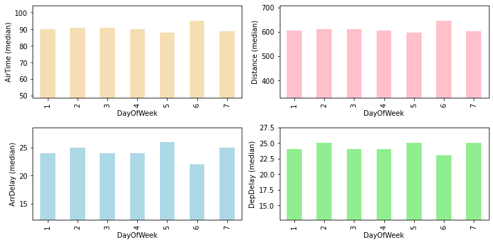

```python
weeks_df = rankings_df.copy()

x = ["AirTime", "Distance", "ArrDelay", "DepDelay", "DayOfWeek"]     #filtering the df
weeks_df = weeks_df[x].groupby("DayOfWeek").aggregate(np.median)       #grouping the data by DayOfWeek

fig, axes = plt.subplots(nrows=2, ncols=2, figsize=(10,5))     #code that would build a [2,2] subplots set
colors = ['#F5DEB3', 'pink', 'lightblue', 'lightgreen']

y=0
for i in range(2):                                                         #loop that will design subplots 4 times
    for e in range(2):
        weeks_df[x[y]].plot(kind="bar", ax=axes[i,e], ylabel=(x[y] + " (median)"),
        ylim=[(weeks_df[x[y]].min()*0.55),(weeks_df[x[y]].max()*1.1)], color=colors[y])
        y+=1

plt.tight_layout()                                   #arranging the subplots' separation in order to make it look cleaner
```

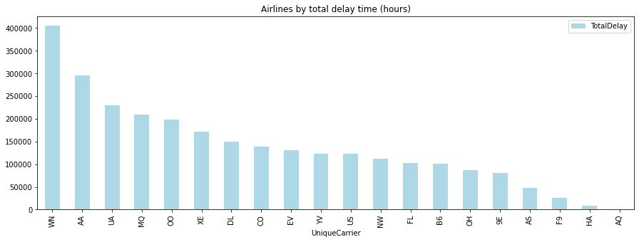

```
               TotalDelay
UniqueCarrier
WN                 405522
AA                 295773
UA                 229411
MQ                 209238
OO                 197822
```

```python
airlines_df = rankings_df.copy()           #copiem el df original "rankings_df" per no modificar-lo quan juguem amb el nou df.

airlines_df["TotalDelay"] = (airlines_df["ArrDelay"] + airlines_df["DepDelay"]) / 60
x = ["UniqueCarrier", "TotalDelay"]
airlines_df = airlines_df[x].groupby("UniqueCarrier").aggregate(sum)    #filter the new df and group by delay time per airline

airlines_df = airlines_df.sort_values(by="TotalDelay", ascending=False)    #creation and display of the bar graphic
airlines_df.plot(kind='bar', figsize=(15,5), color="lightblue")
plt.title("Airlines by total delay time (hours)")
plt.show()

print(airlines_df[:5].astype(int))
```

As we can observe, the Airline with more delayed time is WN, with approx. 400k hours.

### **TOP10 Airports with more delays:**

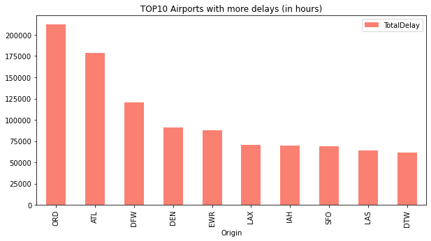

```
        TotalDelay
Origin
ORD         211940
ATL         178541
DFW         120483
DEN          91085
EWR          87826
```

```python
airports_df = rankings_df.copy()    #copiem el df original "rankings_df" per no modificar-lo quan juguem amb el nou df.

airports_df["TotalDelay"] = (airports_df["ArrDelay"] + airports_df["DepDelay"]) / 60      #filtering according to this exercice
x = ["Origin", "Dest", "TotalDelay"]                                                 #columns that we need
airports_df = airports_df[x].groupby("Origin").aggregate(sum)                         #group by Airport of origin...
airports_df = airports_df.sort_values(by="TotalDelay", ascending=False)                #...and sort by total amount of delay

airports_df[:10].plot(kind='bar', figsize=(10,5), color="#FA8072")
plt.title("TOP10 Airports with more delays (in hours)")
plt.show()
print(airports_df[:5].astype(int))
```

The airport with more delays is O'Hare Int'l Airport of Chicago (ORD).

### **Most recurred delay type:**

```
                   Totals
LateAircraftDelay  525950
CarrierDelay       398767
NASDelay           312321
WeatherDelay        77002
```

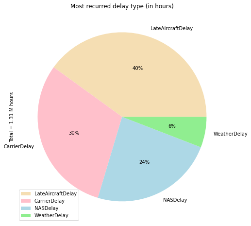

```python
delays = list(df_delays)[2:]
delays_df = rankings_df[delays].copy()     #copiem el df original "rankings_df" per no modificar-lo quan juguem amb el nou df.

delay_sums = delays_df.aggregate(sum)       #save the total value for the plot

delays_df.reset_index(inplace=True)                    #reset the Y axis
delays_df.drop("Date/Flight", axis=1,inplace=True)
delays_df.drop(delays_df.index[:],0,inplace=True)
delays_df.loc["Totals"] = delay_sums/60
suma = delays_df.values.sum().astype(int)

delays_df = delays_df.sort_values(by="Totals", axis=1, ascending=False)      #sort the columns by total value
delays_df = delays_df.astype(int)
delays_df = delays_df.transpose()                                      #transpose the DF in order to run the pie chart
print(delays_df)

delays_df.plot(kind='pie', y="Totals", figsize=(8,8), autopct='%1.0f%%', colors = ['#F5DEB3', 'pink', 'lightblue', 'lightgreen'])
plt.title("Most recurred delay type (in hours)")
plt.ylabel("Total = {:.2f} M hours".format((suma/1000000)))          #creation and display of the pie chart
plt.legend(loc='lower left')
plt.show()
```

Apparently the most recurred delay type is "LateAircraftDelay", hence presumably delays affected by the previous flight.

# Exporta el data set net i amb les noves columnes a Excel.

```python
weekday={1:'Monday', 2:'Tuesday', 3:'Wednesday', 4:'Thursday', 5:'Friday', 6:'Saturday', 7:'Sunday'}
rankings_df["DayOfWeek"] = rankings_df["DayOfWeek"].replace(weekday)

mask = ["DayOfWeek", "AirTime", "Distance", "Origin", "Dest", "ArrDelay",   #create mask to clean the df once again
        "DepDelay", "WeatherDelay", "NASDelay", "LateAircraftDelay"]

length = int(len(rankings_df[mask])/2)     #save length of the Y axis (excel has a limit per sheet and we'll need to halve it)
save_link = r'C:\Users\pacressa\Google Drive\Paul\Formacions\Numbers\CODING\BCN Activa - Data Science (Python)\Sprint 2.2. EEDD i Esctructures de control\S02_T05\DelayedFlights(clean).xlsx'

with pd.ExcelWriter(save_link) as writer:              #save rankings_df to an Excel file, in two different sheets
    rankings_df[mask][:length].to_excel(writer, sheet_name="1")
    rankings_df[mask][length:].to_excel(writer, sheet_name="2")

rankings_df[mask]
```

| Date/Flight | DayOfWeek | AirTime | Distance | Origin | Dest | ArrDelay | DepDelay | WeatherDelay | NASDelay | LateAircraftDelay |
| --- | --- | --- | --- | --- | --- | --- | --- | --- | --- | --- |
| 2008-1-3 (WN335) | Thursday | 116.0 | 810 | IAD | TPA | -14.0 | 8.0 | NaN | NaN | NaN |
| 2008-1-3 (WN3231) | Thursday | 113.0 | 810 | IAD | TPA | 2.0 | 19.0 | NaN | NaN | NaN |
| 2008-1-3 (WN448) | Thursday | 76.0 | 515 | IND | BWI | 14.0 | 8.0 | NaN | NaN | NaN |
| 2008-1-3 (WN3920) | Thursday | 77.0 | 515 | IND | BWI | 34.0 | 34.0 | 0.0 | 0.0 | 32.0 |
| 2008-1-3 (WN378) | Thursday | 87.0 | 688 | IND | JAX | 11.0 | 25.0 | NaN | NaN | NaN |
| ... | ... | ... | ... | ... | ... | ... | ... | ... | ... | ... |
| 2008-12-13 (DL1621) | Saturday | 120.0 | 906 | MSP | ATL | 25.0 | 30.0 | 0.0 | 0.0 | 22.0 |
| 2008-12-13 (DL1631) | Saturday | 78.0 | 481 | RIC | ATL | 75.0 | 57.0 | 57.0 | 18.0 | 0.0 |
| 2008-12-13 (DL1631) | Saturday | 122.0 | 689 | ATL | IAH | 99.0 | 80.0 | 0.0 | 19.0 | 79.0 |
| 2008-12-13 (DL1639) | Saturday | 89.0 | 533 | IAD | ATL | 9.0 | 11.0 | NaN | NaN | NaN |
| 2008-12-13 (DL1641) | Saturday | 104.0 | 874 | SAT | ATL | -5.0 | 7.0 | NaN | NaN | NaN |

1936758 rows × 10 columns

#### (Coming from exercise S03T01)

# - Attachment of plots derived from the flight delays dataframe:

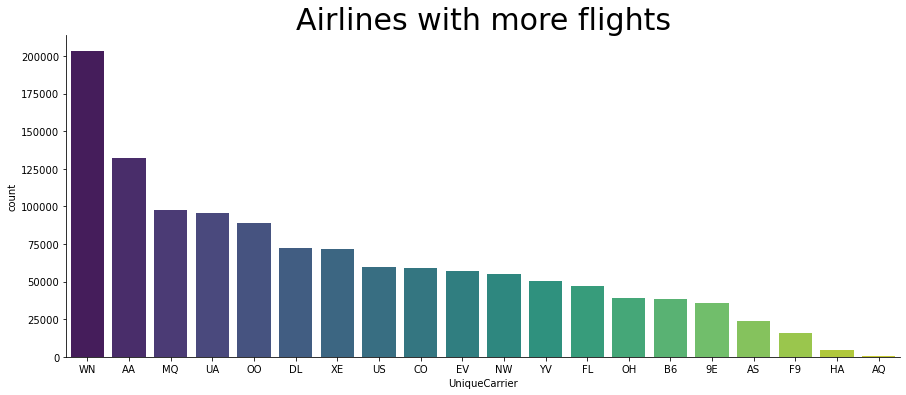

Looks like the top airline carriers in terms of number of flights in the database are WN (by far), AA, MQ and UA.

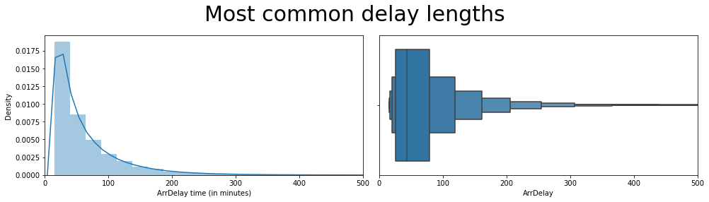

Apparently the most repeated ArrDelay times are gathered between 0 and 100 minutes.

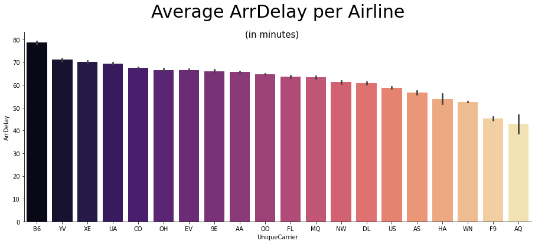

We can assure that the airline with higher average delay at the arrival is B6 with approx. 77 minutes per delayed flight.

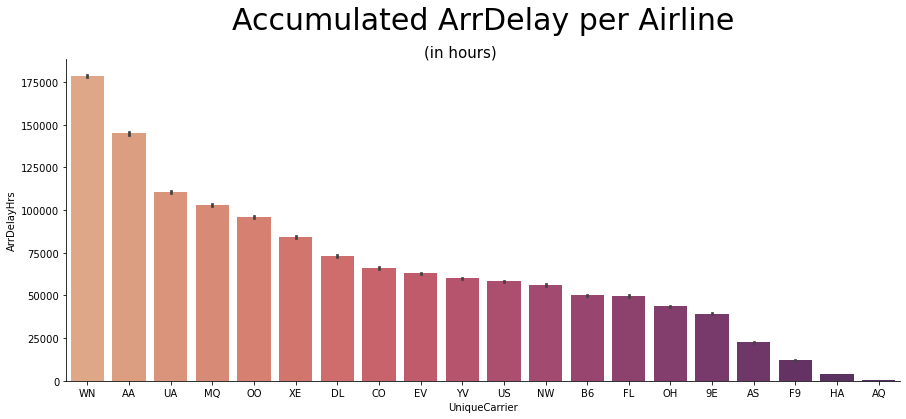

And on the other hand, we can conclude that the airline with more accumulated ArrDelay time is WN. The ranking looks pretty similar to the 'Airlines with more flights' plot. This is because every flight that's registered for each airline, counts approximately as 1 hour for that airline --> Parting from the average ArrDelay data, we know that the average delay time per flight (for any given airline) is 63 minutes:

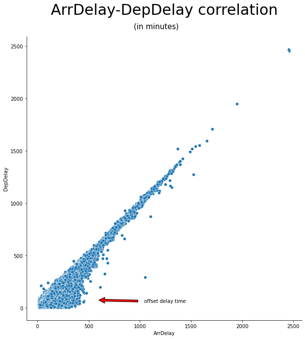

This plot helps us to spot the relation between the departure delay time of a flight considering how late arrived at the airport. In general terms there's a relation of 1:1 as the longer the ArrDelay the longer the DepDelay is. But there's a remarkable number of flights that despite being a delay on the arrival, the DepDelay is not of the same length. That could mean that in those flights the rest time in the airport has been shortened to offset the ArrDelay time.

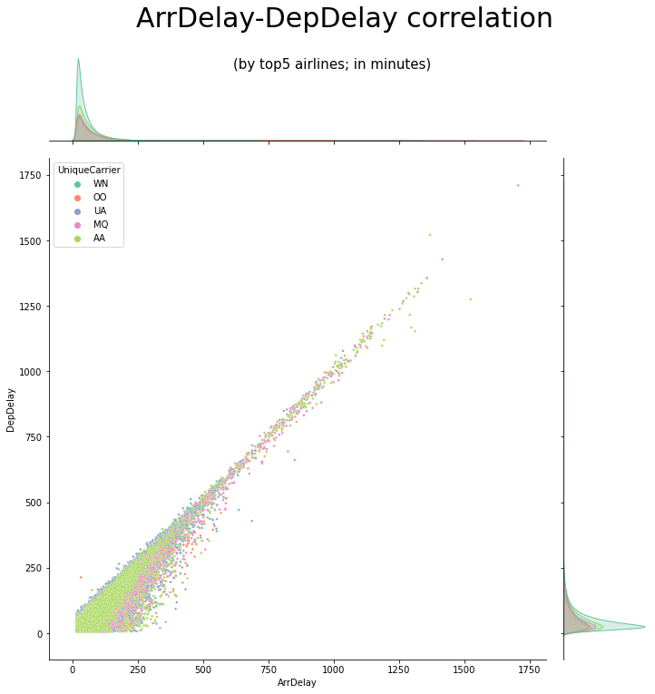

Thanks to this plot we can see that the top5 arilines in terms of number of flights share the same pattern discussed before.

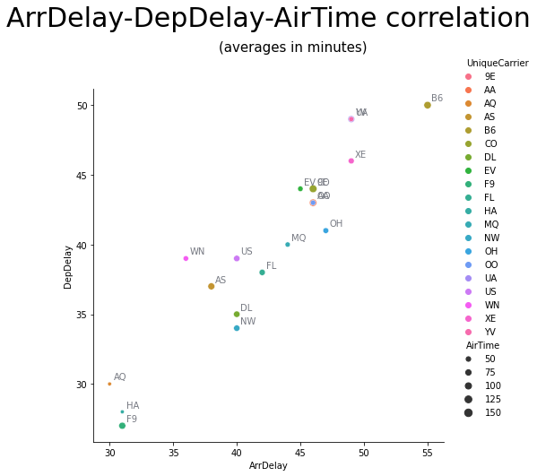

With this last plot we included the correlation between arrival delays, departure delays and air time, grouped by Airline. One conclusion we can draw is there's a 1:1 correlation between how late the airplane departs compared to how late it arrived. On the other hand, we can assess the ranking of airlines in terms of average delays, being B6 the highest and F9 the lowest. In the plot we can also see each airline avare time of flight, represented by the size of the marker. However, the 5 diferent sizes of marker are spread across the plot, meaning that there's no correlation between the length of the flight and its delay values.